# References

https://machinelearningmastery.com/logistic-regression-for-machine-learning/  
https://beckernick.github.io/logistic-regression-from-scratch/

https://onlinecourses.science.psu.edu/stat504/node/150/  
https://newonlinecourses.science.psu.edu/stat501/node/374/

```python
# Start by importing the needed libs
import numpy as np
import pandas as pd
import matplotlib.pyplot as plt
import seaborn as sns; sns.set()
import warnings
warnings.filterwarnings('ignore')
```

# Logistic Regression

In this tutorial we build upon Linear regression to perform logistic regression. The most basic of generalized linear models.  
Linear Reg: Predicts the expected values of the response variable  
Logistic Reg: Predicts the probability of the response in taking a binary value

Binary: Response variable may only take 1 of two values Nominal: Response variable may take 3 or more values with no NATURAL ordering Ordinal: Response variable may take 3 or more ordered values with uneven spacing/intervals between them

Examples:  
Binary: (yes,no) (true,false) etc  
Nominal: Category 1, Category 2 etc etc  
Ordinal: survey data from a hot wings contest where people are asked to rank the hot wing heat between 1 and 5. the difference between a 1 & 2 would differ from person to person

## Binary Form

Examples: What's the probability of getting a job given certain education What's the probability of passing a test given gender

Notice that in both of these examples the predictor in not numerical, however that makes no difference to logistic reg. Linear reg requires it.

### The Math

Define the logistic function as: $$ logit(x) = \frac{1}{1+e^{-x}} $$ (NB: Machine Learning algos may call this the sigmoid function)

then our model is $$ P(Y=1) = P(Y=1 \text{ | } X) = \frac{ e^{b_0+b_1X} }{1+e^{b_0+b_1X}} $$ Note that $$ Ln( \frac{P(Y=1)}{1-P(Y=1)}) = b_0+b_1X $$ Showing the relationship between the linear model and the logistic. To make this a binary regression we would create a rule to map probabilites unto a binary value (ie: If P(Y=1|X) > 0.5 then 1 else 0 ). To fit this model we find $b_0 \text{ and } b_1$. Linear reg estimates the co-efficients by minimizing the sum of squares. Logistic reg maximizes the likelihood function. In layman terms this means that we need to find $b_0 \text{ and } b_1$ that best approximate the observed data. Thankfully python has already done all this for us. so let's get to an example

NB: $\frac{P(Y=1)}{1-P(Y=1)}$ is called the odds. ln(odds) is the log-odds or probit  
Then it follows that $odds = e^{b_0+b_1X}$.

## Example

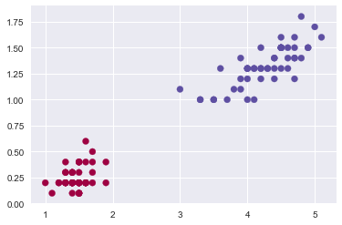

```python
df = pd.read_csv('Data/001LogisticRegression_Iris.csv')
#id is irrelevant
df = df.drop(['Id'],axis=1)
#df.groupby(['Species']).size()

#turn this into a binary problem by dropping Iris-virginica
df = df.drop( df[df.Species == 'Iris-virginica'].index ,axis=0)

#turn text category into binary 1/0
encoding = {"Iris-setosa":0, "Iris-versicolor":1  }
df.replace(encoding,inplace=True)
#Check   df.groupby(['Species']).size()
#Check   df.head()

# I'd like to slim things down even further so
#c = df.corr()

#For those that prefer a visual
#f, ax = plt.subplots(figsize=(11, 9))
#sns.heatmap(c)

# PetalLengthCm,PetalWidthCm have the highest correlation
# we drop the other two
df = df.drop(['SepalLengthCm','SepalWidthCm'],axis=1)
df.head()  #Finally looks good for our purposes

plt.scatter(df['PetalLengthCm'],df['PetalWidthCm'],c=df['Species'],cmap=plt.cm.Spectral )
plt.show()
```

```python
#As usual the modeling is quite trivial in python
from sklearn.linear_model import LogisticRegression

logReg = LogisticRegression(random_state=0, solver='lbfgs')

X = df[['PetalLengthCm','PetalWidthCm']].values
y = df['Species'].values
clf = logReg.fit(X, y)

print(clf.predict(X))
#print(clf.predict_proba(X) ) This is a large array of probabilities
print(clf.score(X, y))        #accuracy = predictions vs actual
```

```
[0 0 0 0 0 0 0 0 0 0 0 0 0 0 0 0 0 0 0 0 0 0 0 0 0 0 0 0 0 0 0 0 0 0 0 0 0
 0 0 0 0 0 0 0 0 0 0 0 0 0 1 1 1 1 1 1 1 1 1 1 1 1 1 1 1 1 1 1 1 1 1 1 1 1
 1 1 1 1 1 1 1 1 1 1 1 1 1 1 1 1 1 1 1 1 1 1 1 1 1 1]
1.0
```

We achieved a 100% accuracy in our predictions. This isn't surprising since our data is super clean